# Linear Model Tests

## Linear model of WCGS

```r
WCGS <- read_csv("https://raw.githubusercontent.com/fabarrios/Regression/master/DataRegressBook/Chap2/wcgs.csv",
                 show_col_types = FALSE)

# behpat personality trait
names(WCGS)
```

```
##  [1] "age"      "arcus"    "behpat"   "bmi"      "chd69"    "chol"
##  [7] "dbp"      "dibpat"   "height"   "id"       "lnsbp"    "lnwght"
## [13] "ncigs"    "sbp"      "smoke"    "t1"       "time169"  "typchd69"
## [19] "uni"      "weight"   "wghtcat"  "agec"
```

```r
WCGS_n <- WCGS %>% mutate( arcus <- factor(arcus))
WCGS_n <- WCGS_n %>%
    mutate(smoke = smoke %>% fct_relevel("No", "Yes"))
```

The variable `chd69` shows whether or not the subject had a coronary event. Other interesting variable to relate to the cholesterol level in blood is the *arcus senilis*, a milky ring in the iris associated with high cholesterol levels, `arcus` is a variable with 1 for presence of the arcus senilis and 0 for the reference group.

```r
# Model of the cholesterol vs BMI in middle aged men
cholBmi_mod1 <- lm(chol ~ bmi + arcus, data = WCGS_n)
summary(cholBmi_mod1)
```

```
##
## Call:
## lm(formula = chol ~ bmi + arcus, data = WCGS_n)
##
## Residuals:
##     Min      1Q  Median      3Q     Max
## -117.03  -28.59   -2.67   26.49  415.01
##
## Coefficients:
##             Estimate Std. Error t value Pr(>|t|)
## (Intercept) 191.5822     7.4145  25.839  < 2e-16 ***
## bmi           1.2747     0.2994   4.257 2.13e-05 ***
## arcus        11.7583     1.6772   7.011 2.89e-12 ***
## ---
## Signif. codes:  0 '***' 0.001 '**' 0.01 '*' 0.05 '.' 0.1 ' ' 1
##
## Residual standard error: 42.99 on 3137 degrees of freedom
##   (14 observations deleted due to missingness)
## Multiple R-squared:  0.0204, Adjusted R-squared:  0.01977
## F-statistic: 32.66 on 2 and 3137 DF,  p-value: 9.193e-15
```

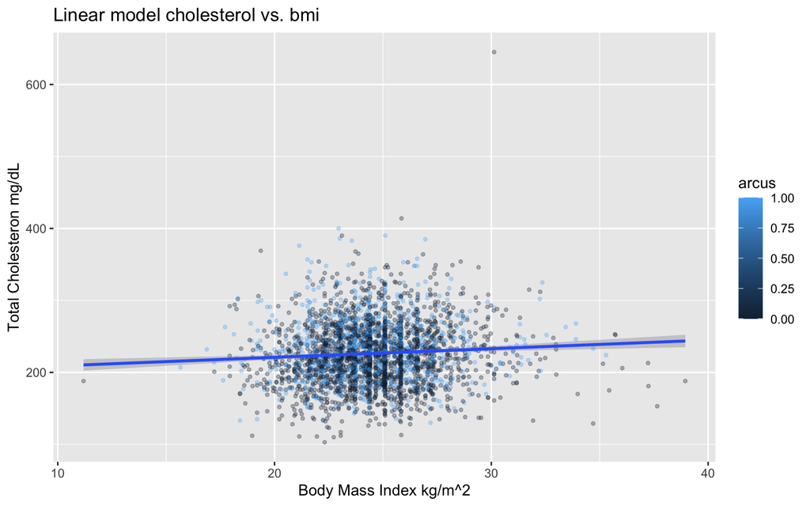

```r
# Plot of chol ~ bmi data
ggplot(data = WCGS_n, aes(x = bmi, y = chol, color = arcus)) +
  labs(x = "Body Mass Index kg/m^2",
       y = "Total Cholesteron mg/dL",
       title = "Linear model cholesterol vs. bmi") +
  geom_point(shape = 20, alpha = 0.3) +
  geom_smooth(method = "lm", formula = y ~ x)
```

Other more complex model includes the `age` and `smoke` variables

```r
# Multipredictor model2
cholBmi_mod2 <- lm(chol ~ bmi + arcus + smoke + age, data = WCGS_n)
summary(cholBmi_mod2)
```

```
##
## Call:
## lm(formula = chol ~ bmi + arcus + smoke + age, data = WCGS_n)
##
## Residuals:
##     Min      1Q  Median      3Q     Max
## -126.94  -28.17   -2.62   24.78  419.25
##
## Coefficients:
##             Estimate Std. Error t value Pr(>|t|)
## (Intercept) 158.3914     9.7715  16.210  < 2e-16 ***
## bmi           1.4799     0.3004   4.926 8.83e-07 ***
## arcus         9.8628     1.7002   5.801 7.25e-09 ***
## smokeYes      8.8635     1.5452   5.736 1.06e-08 ***
## age           0.5296     0.1407   3.765  0.00017 ***
## ---
## Signif. codes:  0 '***' 0.001 '**' 0.01 '*' 0.05 '.' 0.1 ' ' 1
##
## Residual standard error: 42.69 on 3135 degrees of freedom
##   (14 observations deleted due to missingness)
## Multiple R-squared:  0.03479,    Adjusted R-squared:  0.03356
## F-statistic: 28.25 on 4 and 3135 DF,  p-value: < 2.2e-16
```

## Test of two nested linear models

We can compare two linear models, we sill use the definition of a nested model. We have a model that we call the full model
$$Y = \beta_0 + \beta_1 x_1 + \beta_2 x_2 +
\beta_3 x_3 + \beta_4 x_4 + \epsilon$$
and we want to compare to a nested model. A nested model is defined like the full model with *less* variables included in the model.
$$Y = \beta_0 + \beta_1 x_1 + \beta_2 x_2 +
\epsilon$$
To compare the two models we use the null hypothesis: $H_0$: both, the full and the nested models fit the data equally well. (if you cannot discard $H_0$ therefore you should take the nested model, Occam’s razor). And the alternative hypothesis is $H_1$: the full model significantly outperforms the nested model (conclusion: you keep the full model).
We can estimate the comparison of a full model and nested models using the `anova` R function, or other more complex methods like the likelihood ration test from `lmtest` package, to compare `cholBmi_mod2` to `cholBmi_mod1` models with anova and the likelihood ratio test we run.

```r
# using the anova R test to compare the models
anova(cholBmi_mod2, cholBmi_mod1)
```

```
## Analysis of Variance Table
##
## Model 1: chol ~ bmi + arcus + smoke + age
## Model 2: chol ~ bmi + arcus
##   Res.Df     RSS Df Sum of Sq     F    Pr(>F)
## 1   3135 5712333
## 2   3137 5797537 -2    -85204 23.38 8.336e-11 ***
## ---
## Signif. codes:  0 '***' 0.001 '**' 0.01 '*' 0.05 '.' 0.1 ' ' 1
```

```r
# Comparing model2 (fullmodel) with model1 (nested linear model)
# likelihood ratios test
lrtest(cholBmi_mod2, cholBmi_mod1)
```

```
## Likelihood ratio test
##
## Model 1: chol ~ bmi + arcus + smoke + age
## Model 2: chol ~ bmi + arcus
##   #Df LogLik Df Chisq Pr(>Chisq)
## 1   6 -16240
## 2   4 -16263 -2 46.49  8.033e-11 ***
## ---
## Signif. codes:  0 '***' 0.001 '**' 0.01 '*' 0.05 '.' 0.1 ' ' 1
```

If the p-value associated with the extra parameters is low, it suggests that removing it does significantly affect the model’s explanatory power, suggesting that it is better to keep the full model.

## Testing for nonlinearities

The Test of Concavity/Convexity, often referred to as the Rainbow Test, is a statistical method used primarily in regression analysis to determine whether a model is correctly specified as linear or if it exhibits non-linear characteristics, such as convexity or concavity. The test is constructed assuming the linear model is correct, Null Hypothesis: The null hypothesis of the test posits that the regression model is correctly specified as linear.  
A low p-value (typically below 0.05) would lead to rejection of the null hypothesis, suggesting that the model may not be linear.

```r
# Non linear testing the model between chol ~ age
# Test of concavity/convexity (rainbow test)

chol_age_mod <- lm(chol ~ age, data = WCGS_n)
summary(chol_age_mod)
```

```
##
## Call:
## lm(formula = chol ~ age, data = WCGS_n)
##
## Residuals:
##     Min      1Q  Median      3Q     Max
## -130.20  -28.88   -2.84   26.10  420.93
##
## Coefficients:
##             Estimate Std. Error t value Pr(>|t|)
## (Intercept) 193.8989     6.5176  29.750  < 2e-16 ***
## age           0.7018     0.1399   5.018 5.52e-07 ***
## ---
## Signif. codes:  0 '***' 0.001 '**' 0.01 '*' 0.05 '.' 0.1 ' ' 1
##
## Residual standard error: 43.25 on 3140 degrees of freedom
##   (12 observations deleted due to missingness)
## Multiple R-squared:  0.007955,   Adjusted R-squared:  0.007639
## F-statistic: 25.18 on 1 and 3140 DF,  p-value: 5.519e-07
```

```r
#
raintest(chol_age_mod, fraction = 0.5, order.by = "mahalanobis", data = WCGS_n)
```

```
##
##  Rainbow test
##
## data:  chol_age_mod
## Rain = 0.98345, df1 = 1571, df2 = 1569, p-value = 0.6295
```

We may conclude that the model of cholesterol with age is linear.